# R Markdown Supplement: GP modeling of mortality surfaces

Jimmy Risk, Mike Ludkovski

April 8 2024

The following notebook is an electronic supplement to the chapter *Gaussian Process Models for Financial Mathematics and Actuarial Science* by M. Ludkovski and J. Risk.

In particular, most of the plots and figures appearing in **Section 3** of the manuscript can be obtained by executing the code below. By modifying the input datasets to include other countries/genders/sub-populations (see the provided dataset for Latvia with a matching format to Denmark), similar analysis can be extended by the readers.

# Accessing Mortality Data

We make use of the following packages * [`DiceKriging`](https://cran.r-project.org/web/packages/DiceKriging/DiceKriging.pdf): kriging methods for single-output GP (SOGP). * [`rgenoud`](https://cran.r-project.org/web/packages/rgenoud/rgenoud.pdf): genetic optimization solver used for Maximum Likelihood Estimation of GP hyperparameters. * [`data.table`](https://cran.r-project.org/web/packages/data.table/data.table.pdf): extension of `data.frame` to enhance data manipulation.

The script in the `createMortData.R` loads the csv files containing the Deaths and Exposures for the respective population.

```r
library(dplyr)
library(rgenoud)
library(DiceKriging)
library(data.table)
library(plot3D)
source("createMortData.R")
```

The input data should be an `R` dataframe with factors **age**, **year**, **deaths** and **exposures**. The corresponding log mortality rates are computed as
$$y^n = \log(D^n/E^n)$$
where $D^n$ and $E^n$ are, respectively, the number of deaths and midyear count of exposed lives for the $n$th age/year pair $\mathbf{x}^n = (x^n_{ag}, x^n_{yr})$.

For the illustrations below we work with the dataset for Denmark Males.

```r
mortData = createMortData(year_start=1990, year_end=2016,
                          age_start=60, age_end=80,
                          sex="m", sex_cat="no")  # M=males
mortData = mortData[country %in% c("Denmark")]
head(mortData)
```

```
##      age  year country       rate         y
##    <num> <int>  <char>      <num>     <num>
## 1:    60  1990 Denmark 0.01561052 -4.159810
## 2:    60  1991 Denmark 0.01602873 -4.133373
## 3:    60  1992 Denmark 0.01762344 -4.038525
## 4:    60  1993 Denmark 0.01486386 -4.208822
## 5:    60  1994 Denmark 0.01553909 -4.164396
## 6:    60  1995 Denmark 0.01599507 -4.135475
```

# Fitting the baseline GP model

For our Gaussian Process Regression models, we utilize the package `DiceKriging` available on CRAN.

The function **km()** is used to fit a GP model based on input-output set $(x,y)$ and the following parameters:

```r
xMort <- data.frame(age = mortData$age, year = mortData$year)
yMort <- mortData$y
mortModel_nug <- km(formula = ~x.age,
                    design = data.frame(x = xMort), response = yMort,
                    nugget.estim=TRUE,
                    covtype="matern5_2",
                    optim.method="gen",
                    # the "control" parameters below handle speed versus risk of
                    # converging to local minima.  See "rgenoud" package for details
                    control=list(max.generations=100,pop.size=100,wait.generations=8,
                                 solution.tolerance=1e-5,trace=F))
```

```r
mortModel_nug
```

```
##
## Call:
## km(formula = ~x.age, design = data.frame(x = xMort), response = yMort,
##     covtype = "matern5_2", nugget.estim = TRUE, optim.method = "gen",
##     control = list(max.generations = 100, pop.size = 100, wait.generations = 8,
##         solution.tolerance = 1e-05, trace = F))
##
## Trend  coeff.:
##                Estimate
##  (Intercept)    -9.8522
##        x.age     0.0919
##
## Covar. type  : matern5_2
## Covar. coeff.:
##                 Estimate
##  theta(x.age)    24.2748
## theta(x.year)     9.8818
##
## Variance estimate: 0.03687716
##
## Nugget effect estimate: 0.001787389
```

The above code output shows estimates of (in order) $\beta_0, \beta^1_{ag}, \theta_{ag}, \theta_{yr}, \eta^2$ and $\sigma^2_{\epsilon}$. Despite the assumption of a nugget effect, **km()** by default treats the observations as without having noise variance. To be consistent with our setting, we re-enter the model using the above fitted parameters along with inputting **noise.var**:

```r
nug <- mortModel_nug@covariance@nugget
mortModel <- km(formula = ~x.age, design = mortModel_nug@X,
                response = mortModel_nug@y,
                noise.var = rep(nug,mortModel_nug@n),
                coef.trend = mortModel_nug@trend.coef,  # re-use obtained hyperparameters
                coef.cov = mortModel_nug@covariance@range.val,
                coef.var = mortModel_nug@covariance@sd2,
                covtype = mortModel_nug@covariance@name)
```

## Figure 7: raw and predicted mortality surfaces

We use the **plot3D** library to visualize the raw log-mortality surface (the ribbons emphasize that data is collected annually) for Males in Denmark.

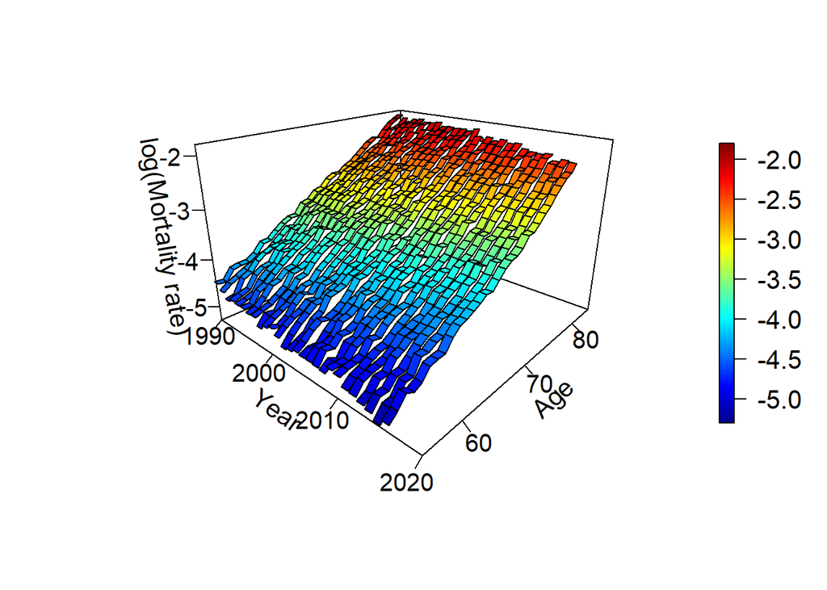

```r
agesObserved <- 55:84
yearsObserved <- 1990:2016
mortData_ext = createMortData(year_start=min(yearsObserved), year_end=max(yearsObserved),
age_start=min(agesObserved), age_end=max(agesObserved), sex="m", sex_cat="no")
mortData_ext = mortData_ext[country %in% c("Denmark")]

rateObserved <- dplyr::filter(mortData_ext,age %in% agesObserved, year %in% yearsObserved)$rate
rateObserved <- matrix(log(rateObserved),nrow=length(yearsObserved));

ribbon3D(yearsObserved,agesObserved, z=rateObserved, along="y", expand=0.67,
                    border="black", zlim=c(-5.3,-1.8), phi=22, theta=42, xlim=c(1990,2020),
                    xlab="Year",ylab="Age",zlab="log(Mortality rate)", space=0.1,
                    colkey = list(plot=FALSE), clim=c(-5.3, -1.8),
                    ticktype="detailed" , nticks=4, cex.axis=1.25, cex.lab=1.3)
colkey(side=4, length = 0.75, width = 0.6, dist=-0.09,
       cex.axis=1.3, clim=c(-5.3,-1.8), add=TRUE)
```

We then show the smooth surface based on GP projections from the previous **mortModel**. The predictive surface extends beyond the range of observed data: covering Ages $[55,85]$ in the plot (beyond the training range of $[60,80]$) and covering the future years of 2017–2024 relative to the training range of 1990–2016.

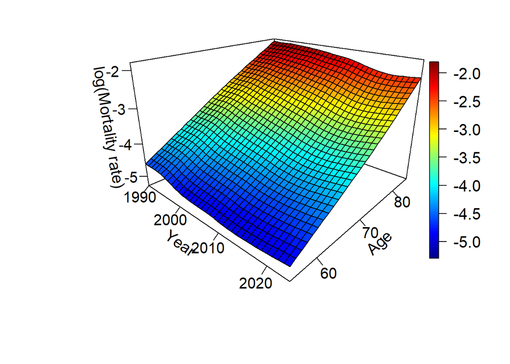

```r
agesForecast <- 55:85
yearsForecast <- 1990:2024
par(mar=c(5,5,2,2))

# build data frame for desired forecasts, then call predict
xPredImage <- data.frame(expand.grid(agesForecast, yearsForecast))
colnames(xPredImage) <- c("age","year")

mortPredImage <- predict(mortModel, newdata=data.frame(x=xPredImage),
                    cov.compute=TRUE,
                    se.compute=TRUE,type="UK")
mortPredImage <- matrix(mortPredImage$m,nrow=length(yearsForecast),byrow=TRUE)

persp3D(yearsForecast,agesForecast, z=mortPredImage,border="black",
        xlab="Year", ylab="Age", zlab="log(Mortality rate)",
        zlim=c(-5.3,-1.8), colkey = FALSE, clim=c(-5.3, -1.8),
        ticktype="detailed", phi=22, theta=42, expand=0.67,
        cex.axis=1.25, cex.lab=1.3, nticks=4 )
colkey(side=4, length = 0.75, width = 0.6, dist=-0.12,
       cex.axis=1.3, clim=c(-5.3,-1.8), add=TRUE)
```

# Fig 8 left: In-sample Smoothing: Age Structure of Mortality

We begin with producing plots of estimated (smoothed) mortality rates to show the mortality *age structure*, i.e., how in a given year mortality depends on Age. On the log-scale, the Gompertz law implies a roughly linear relationship.

After constructing a **km** object, the main workhorse is the **predict()** command. Among its outputs are the posterior mean, posterior standard deviation, and $95\%$ credible bands. The **predict()** command allows for *any* test set with the same number of covariates as the training set. In our case, we may get a 2-d posterior mortality surface for any ages and years desired to forecast upon. We use the library **dplyr** for easier data handling.

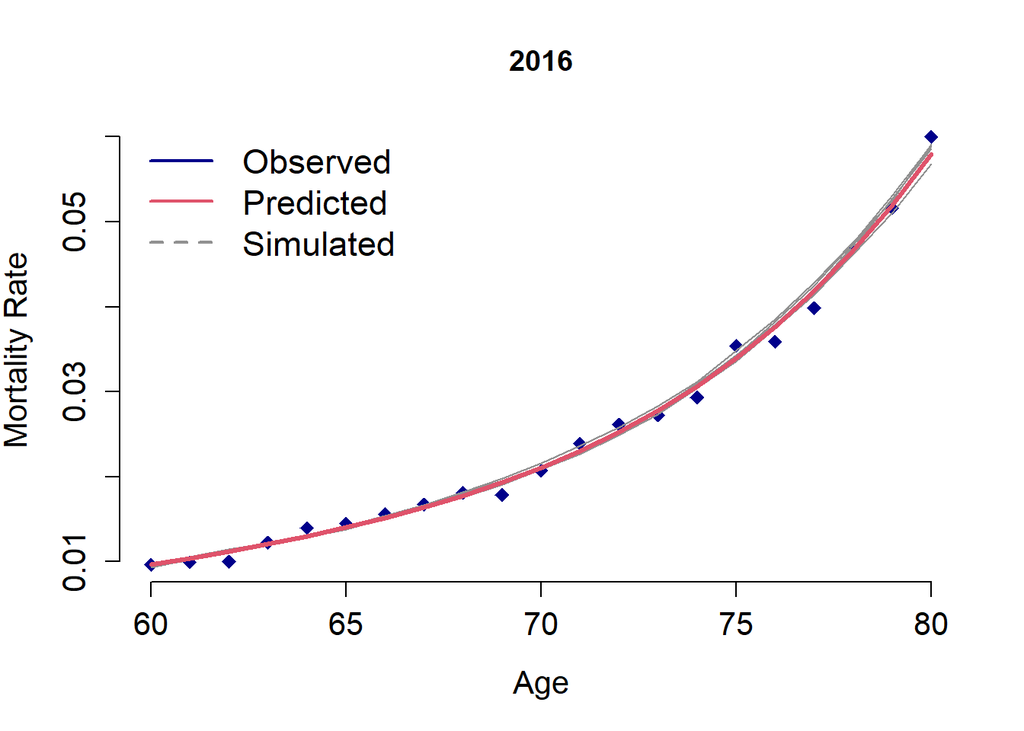

```r
agesForecast <- seq(60,80, 1)
yearsForecast <- 2016

# raw data
rateObserved <- dplyr::filter(mortData,age %in% agesForecast, year %in% yearsForecast)$rate
# build data frame for desired forecasts, then call predict
xPred <- data.frame(age=agesForecast,year=yearsForecast)
mortPred <- predict(mortModel, newdata=data.frame(x=xPred),
                    cov.compute=TRUE,
                    se.compute=TRUE, type="UK")

# generate 5 conditional simulations from the GP posterior
nsim <- 5
sim <- simulate(mortModel, nsim=nsim, newdata = data.frame(x=xPred), cond=TRUE,
                  nugget.sim=nug/100)

# plot mortality as a function of age
plot(agesForecast,rateObserved, pch=18, main="2016",
     xlab="Age", ylab="Mortality Rate",
     cex.axis=1.3, cex.lab=1.3, cex=1.3,
     xlim=c(60,80), bty="n", col="darkblue")

for(i in 1:nsim){
    lines(agesForecast,exp(sim[i,]),col="grey57")
}
lines(agesForecast,exp(mortPred$mean),col=2,lty=1,lwd=3)

legend("topleft",c("Observed","Predicted","Simulated"),
       lwd=c(2,2), lty=c(1,1,2), col=c("darkblue",2,"grey57"),
       cex=1.4, bty="n")
```

## Fig 8 right: Mortality over time

We can also produce a plot with year on the $x$-axis. Below, we additionally illustrate use of $95\%$ credible intervals that quantify the (statistical) credibility of the smoothing. Our implementation of building a model with noise variance equal to the nugget causes **predict()** to return credible bands for the true surface $f$ and not the observation process $y$. Thus we need to add $\sigma^2$ to achieve the bands for the observed mortality $y$ that would be relevant for coverage tests.

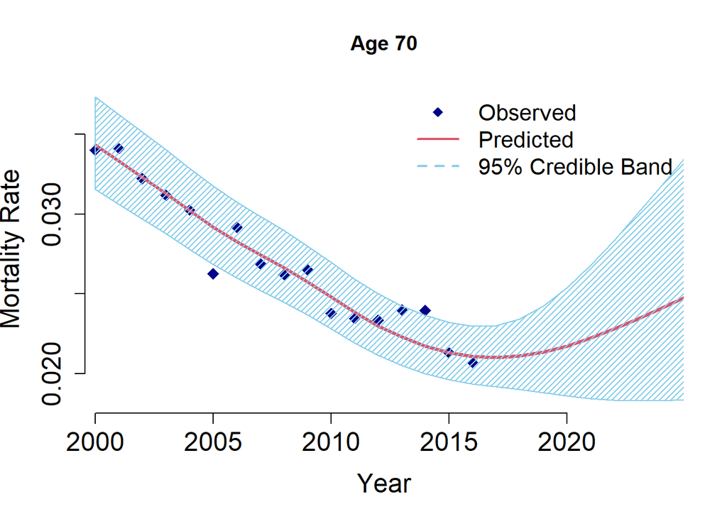

```r
agesForecast <- 70
yearsForecast <- 2000:2026
yearsObserved <- 1999:2016

nYr <- length(yearsForecast)
nAg <- length(agesForecast)
xPred <- data.frame(age=rep(agesForecast,each=nYr), year=rep(yearsForecast,nAg))

mortPred <- predict(mortModel, newdata=data.frame(x=xPred), cov.compute=TRUE,
             se.compute=TRUE, type="UK")

xPred$m <- mortPred$mean
y_sd = sqrt((mortPred$sd ^2) + nug)
xPred$lower95  = mortPred$mean - 1.96 * y_sd # predictive CI for y at 95% using z_0.975=1.96
xPred$upper95  = mortPred$mean + 1.96 * y_sd

for(ageObs in agesForecast){
  rateObserved <- dplyr::filter(mortData, age == ageObs, year %in% yearsObserved)$rate
  dataPred <- dplyr::filter(xPred, age == ageObs, year %in% yearsForecast)

  # exponentiate to show actual mortality rates (not logged)
  ratePred <- exp(dataPred$m);
  upper95Pred <- exp(dataPred$upper95); lower95Pred <- exp(dataPred$lower95)

  plot(yearsObserved,rateObserved,
       pch=18, main = paste("Age", ageObs),
       xlab="Year", ylab="Mortality Rate",
       cex.axis=1.5, cex.lab=1.5, cex=1.5,
       xlim=c(2000.5,2024), ylim=c(min(lower95Pred),max(upper95Pred)),
       bty="n", col="darkblue")
  lines(yearsForecast,ratePred, col=2, lwd=3)
  polygon(c(yearsForecast,rev(yearsForecast)),c(lower95Pred,rev(upper95Pred)),
          col="skyblue", density=25,lwd=1)

  legend("topright",c("Observed","Predicted","95% Credible Band"),
       lwd=c(2,2,2), lty=c(0,1,2), pch=c(18,NA,NA),
       col=c("darkblue",2,"skyblue"), cex=1.3, bty="n")
}
```

# Fig 9 left: Mortality Improvement

For YoY mortality improvement rates, we calculate the finite difference expression. It is common to interpret a mortality surface is via the (annual) mortality *improvement factors* which measures longevity changes year-over-year. In terms of the observations, the raw annual percentage mortality improvement is:

$$MI^{raw}(\mathbf{x})=1-\dfrac{\exp{\big(y(x_{ag},x_{yr})\big)}}{\exp{\big(y(x_{ag},x_{yr}-1)\big)}}.$$

The smoothed improvement factor is obtained by replacing $y$’s by the GP model posterior $m(\mathbf{x})$’s:
$$MI^{GP}(\mathbf{x}):=1-\dfrac{\exp{\big(m_*(x_{ag},x_{yr})\big)}}{\exp{\big(m_*(x_{ag},x_{yr}-1)\big)}}.$$

The following code produces improvement rates for every odd year and plots them together.

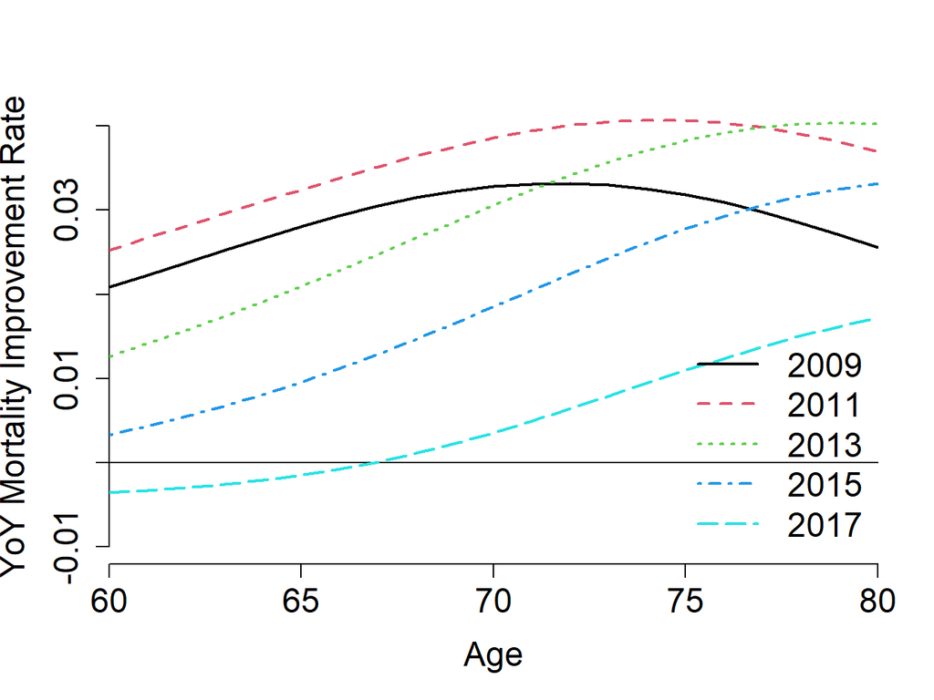

```r
agesForecast <- 60:80
yStart = 2008; yEnd = 2018;
yearsForecast <- yStart:yEnd


nYr <- length(yearsForecast)
nAg <- length(agesForecast)
xPred <- data.frame(age=rep(agesForecast,each=nYr), year=rep(yearsForecast,nAg))
mortPred <- predict(mortModel, newdata=data.frame(x=xPred), cov.compute=TRUE,
             se.compute=TRUE, type="UK")

xPred$m <- mortPred$mean
forwardPred <- dplyr::filter(xPred, age %in% agesForecast, year %in% (yStart+1):yEnd)$m
backwardPred <- dplyr::filter(xPred, age %in% agesForecast, year %in% yStart:(yEnd-1))$m
mibackgp <- 1-exp(forwardPred)/exp(backwardPred)  # GP-smoothed improvement rate
xPred$mibackgp <- NA
xPred$mibackgp[which(xPred$year > yStart)] <- mibackgp

miPlot <- dplyr::filter(xPred, age %in% agesForecast, year == yEnd)$mibackgp
plot(c(0,100), c(0,0), type="l", lwd=1, xlab="Age", xaxs="i",
     ylab="YoY Mortality Improvement Rate",
     cex.axis=1.5, cex.lab=1.5, cex=1.5,
     ylim=c(-0.01, 0.04), xlim=c(60,80),bty='n')
for(yr in seq(yStart+1,yEnd-1,2)){
  # plot the MI for that year
  miPlot <- dplyr::filter(xPred, age %in% agesForecast, year == yr)$mibackgp
  lines(agesForecast, miPlot, col=(yr-2007)/2, lty=(yr-2007)/2, lwd=2)

}
legend("bottomright", legend=seq(yStart+1,yEnd-1,by=2), col=c(1:5,1),
       lwd=rep(2,5), lty=c(1:5,1), cex=1.5, bty='n')
```

## Fig 9 right: Life Expectancy Boxplot

To generate scenarios for period life expectancy, we train a model on a wider range of Ages. In the Danish dataset, observations are reliable up to age 103, so we use that for training the new `mortDataE`. Due to the larger training set (of size 27 x 44 = 1188 training inputs), this takes a couple of minutes.

```r
mortDataE = createMortData(year_start=1990, year_end=2016,
                           age_start=60, age_end=103, sex="m", sex_cat="no")
mortDataE = mortDataE[country %in% c("Denmark")]
control.params = list(max.generations=100,pop.size=100,
                      wait.generations=8,solution.tolerance=1e-5,trace=F)

# fit linear age-year trend model
xMortE <- data.frame(age = mortDataE$age, year = mortDataE$year)
yMortE <- mortDataE$y
mortModelE_nug <- km(formula = ~x.age+x.year,  #linear in age, linear in year
                         design = data.frame(x = xMortE), response = yMortE,
                         nugget.estim=TRUE,
                         covtype="matern5_2",
                         optim.method="gen",
                         control=control.params)

nug_E <- mortModelE_nug@covariance@nugget
mortModelE <- km(formula = ~x.age+x.year,
                     design = mortModelE_nug@X, response = mortModelE_nug@y,
                     noise.var = rep(nug_E,mortModelE_nug@n),
                     coef.trend = mortModelE_nug@trend.coef,
                     coef.cov = mortModelE_nug@covariance@range.val,
                     coef.var = mortModelE_nug@covariance@sd2,
                     covtype = mortModelE_nug@covariance@name)
```

We next generate 200 posterior samples (i.e., scenarios) based on the GP posterior mortality curves in Age for the period Life Expectancy (LE) $e_{65}$ at age 65 from the point of view of Year 2017 through 2026. After aggregating across samples, we visualize the resulting boxplots of projected future $e_{65}$. We find that the model projects an average gain in LE of about 1 year between 2016 and 2026, although the range is from 0 (no gain) to 2+ years of gain

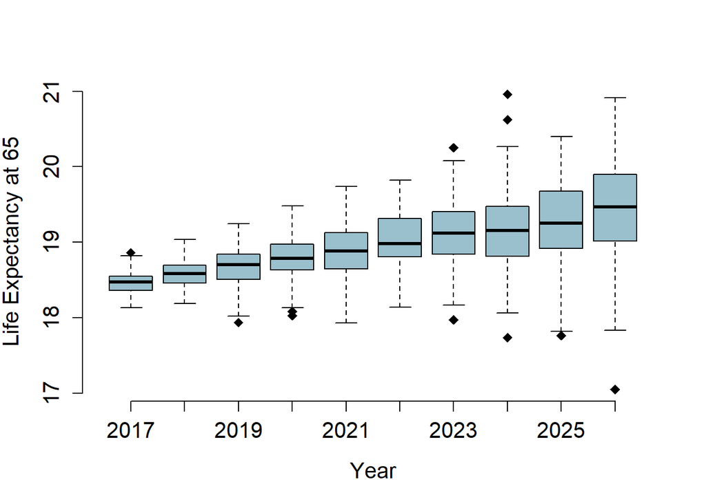

```r
nsim <- 200
maxAge <- 105
agesForecast <- seq(65,maxAge, 1)
lifeExp65 <- array(0, dim=c(10,nsim))  # period life expectancy for each scenario
for (j in 1:10) {
  yearsForecast <- 2016+j #:2026

  xPredE <- data.frame(age=agesForecast,year=yearsForecast)
  mortPredE <- predict(mortModelE, newdata=data.frame(x=xPredE),
                    cov.compute=TRUE,
                    se.compute=TRUE,type="UK")

  sim <- simulate(mortModelE, nsim=nsim, newdata = data.frame(x=xPredE), cond=TRUE,
                  nugget.sim=nug_E/100)

  # first two terms: dying in the 1 year, dying in exactly the second year
  lifeExp65[j,] = exp(sim[,1]) *1 + exp(sim[,2])*(1-exp(sim[,1])) *2
  for (ag in 3:(maxAge-65+1))  # add probability of dying at age 'ag'
      lifeExp65[j,] = lifeExp65[j,] + exp(sim[,ag])*apply( 1-exp(sim[,1:(ag-1)]),1,prod) * ag
}

# Display a boxplot for the distribution of future e_{65}
par(bty="n")
boxplot(t(lifeExp65), pch=18, main="", names=2017:2026, xlab="Year",
        ylab="Life Expectancy at 65",
        cex.axis=1.3, cex.lab=1.3, cex=1.3,col="lightblue3")
```

# Fig 10: Comparison of Mean-function specifications

**km()** takes in an object of class **formula** to specify a trend function, just like with linear OLS model `lm()` and generalized linear model `glm()` fitting. The following code produces models with constant, linear and quadratic trend.

```r
mortData3 <- dplyr::filter(mortData, age %in% 60:80, year %in% 1999:2016)
xMort3 <- data.frame(age = mortData3$age, year = mortData3$year)
yMort3 <- mortData3$y


# fit intercept only model
mortModel3int_nug <- km(formula = ~1,
                    design = data.frame(x = xMort3), response = yMort3,
                    nugget.estim=TRUE,
                    covtype="matern5_2",
                    optim.method="gen",
                    control=control.params)

nug_int <- mortModel3int_nug@covariance@nugget
mortModelint <- km(formula = ~1,
                    design = mortModel3int_nug@X,
                    response = mortModel3int_nug@y,
                    noise.var = rep(nug_int,mortModel3int_nug@n),
                    coef.trend = mortModel3int_nug@trend.coef,
                    coef.cov = mortModel3int_nug@covariance@range.val,
                    coef.var = mortModel3int_nug@covariance@sd2,
                    covtype = mortModel3int_nug@covariance@name)

# fit linear trend model in both age and year
mortModel3lin_nug <- km(formula = ~x.age+x.year,
                    design = data.frame(x = xMort3),
                    response = yMort3,
                    nugget.estim=TRUE,
                    covtype="matern5_2",
                    optim.method="gen",
                    control=control.params)

nug_lin <- mortModel3lin_nug@covariance@nugget
mortModellin <- km(formula = ~x.age+x.year,
                    design = mortModel3lin_nug@X,
                    response = mortModel3lin_nug@y,
                    noise.var = rep(nug_lin,mortModel3lin_nug@n),
                    coef.trend = mortModel3lin_nug@trend.coef,
                    coef.cov = mortModel3lin_nug@covariance@range.val,
                    coef.var = mortModel3lin_nug@covariance@sd2,
                    covtype = mortModel3lin_nug@covariance@name)

# fit quadratic-age trend model: quadratic in age, linear in year
mortModel3quad_nug <- km(formula = ~x.age+I(x.age^2)+x.year,
                         design = data.frame(x = xMort3),
                         response = yMort3,
                         nugget.estim=TRUE,
                         covtype="matern5_2",
                         optim.method="gen",
                         control=control.params)

nug_quad <- mortModel3quad_nug@covariance@nugget
mortModelquad <- km(formula = ~x.age+I(x.age^2)+x.year,
                     design = mortModel3quad_nug@X,
                     response = mortModel3quad_nug@y,
                     noise.var = rep(nug_quad,mortModel3quad_nug@n),
                     coef.trend = mortModel3quad_nug@trend.coef,
                     coef.cov = mortModel3quad_nug@covariance@range.val,
                     coef.var = mortModel3quad_nug@covariance@sd2,
                     covtype = mortModel3quad_nug@covariance@name)
```

Using **show()** we can compare the fitted coefficients of the trends, as well as the GP hyperparameters, such as the lengthscales $\theta_{ag},\theta_{yr}$.

```r
show(mortModelint)
```

```
##
## Call:
## km(formula = ~1, design = mortModel3int_nug@X, response = mortModel3int_nug@y,
##     covtype = mortModel3int_nug@covariance@name, coef.trend = mortModel3int_nug@trend.coef,
##     coef.cov = mortModel3int_nug@covariance@range.val, coef.var = mortModel3int_nug@covariance@sd2,
##     noise.var = rep(nug_int, mortModel3int_nug@n))
##
## Trend  coeff.:
##
##  (Intercept)    -3.5477
##
## Covar. type  : matern5_2
## Covar. coeff.:
##
##  theta(x.age)    32.6597
## theta(x.year)    34.0000
##
## Variance: 1.260233
```

```r
show(mortModellin)
```

```
##
## Call:
## km(formula = ~x.age + x.year, design = mortModel3lin_nug@X, response = mortModel3lin_nug@y,
##     covtype = mortModel3lin_nug@covariance@name, coef.trend = mortModel3lin_nug@trend.coef,
##     coef.cov = mortModel3lin_nug@covariance@range.val, coef.var = mortModel3lin_nug@covariance@sd2,
##     noise.var = rep(nug_lin, mortModel3lin_nug@n))
##
## Trend  coeff.:
##
##  (Intercept)    40.8069
##        x.age     0.0965
##       x.year    -0.0255
##
## Covar. type  : matern5_2
## Covar. coeff.:
##
##  theta(x.age)     5.1059
## theta(x.year)     4.4595
##
## Variance: 0.001748809
```

```r
show(mortModelquad)
```

```
##
## Call:
## km(formula = ~x.age + I(x.age^2) + x.year, design = mortModel3quad_nug@X,
##     response = mortModel3quad_nug@y, covtype = mortModel3quad_nug@covariance@name,
##     coef.trend = mortModel3quad_nug@trend.coef, coef.cov = mortModel3quad_nug@covariance@range.val,
##     coef.var = mortModel3quad_nug@covariance@sd2, noise.var = rep(nug_quad,
##         mortModel3quad_nug@n))
##
## Trend  coeff.:
##
##  (Intercept)    44.2130
##        x.age     0.0292
##   I(x.age^2)     0.0005
##       x.year    -0.0260
##
## Covar. type  : matern5_2
## Covar. coeff.:
##
##  theta(x.age)     4.9116
## theta(x.year)     3.2770
##
## Variance: 0.001201956
```

We can also print out the respective log-likelihood scores that can be converted into BIC scores and ultimately into Bayes Factors for comparing goodness-of-fit across models. As expected, the quadratic prior mean has the highest log-likelihood because it has the most degrees of freedom. However, after applying the BIC penalties, the linear-mean model ends up with the highest BIC.

```r
c(mortModel3int_nug@logLik,mortModel3lin_nug@logLik,mortModel3quad_nug@logLik)
```

```
## [1] 616.2822 633.9895 635.7808
```

Next, we use these three GP models to forecast temporal mortality trends at ages 60, 70, 80, to see how well they can extrapolate. In the plots below we compare their Age-specific forecasts for years 2005–2030, where 2017 and onward is an extrapolation compared to the training data.

*Note:* we plot all the GP predictions on the same plot since we have the natural ordering that (log-)mortality is much lower at Age 60 compared to Age 70 compared to Age 80.

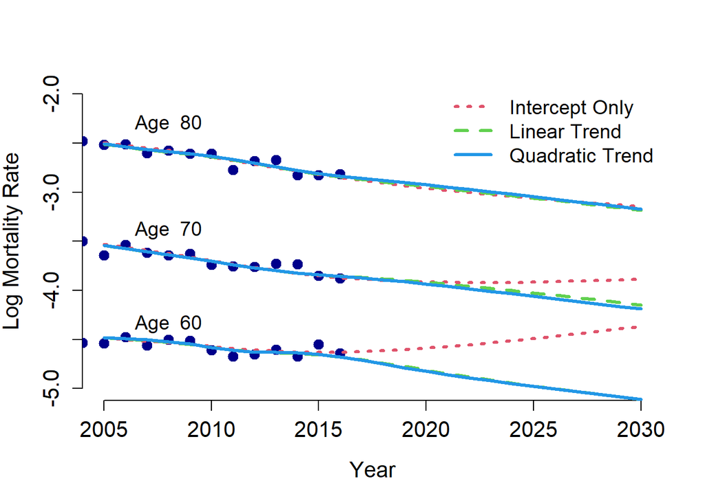

```r
# Setup the test data.frame to be displayed
agesForecast <- c(60,70,80)
yearsForecast <- 2005:2030
nYr <- length(yearsForecast)
nAg <- length(agesForecast)
xPred <- data.frame(age=rep(agesForecast,each=nYr), year=rep(yearsForecast,nAg))

# Setup the raw training data that was used
agesObserved <- 60:80
yearsObserved <- 1999:2016
rateObserved <- dplyr::filter(mortData,age %in% agesObserved, year %in% yearsForecast)$rate

# predict using the 3 GP models above on the same test set
mortPredInt <- predict(mortModelint, newdata=data.frame(x=xPred),
                       cov.compute=TRUE,  se.compute=TRUE,type="UK")
mortPredLin <- predict(mortModellin, newdata=data.frame(x=xPred),
                       cov.compute=TRUE, se.compute=TRUE,type="UK")
mortPredQuad <- predict(mortModelquad, newdata=data.frame(x=xPred),
                        cov.compute=TRUE, se.compute=TRUE,type="UK")

xPred$mInt <- (mortPredInt$mean)
xPred$mLin <- (mortPredLin$mean)
xPred$mQuad <- (mortPredQuad$mean)


xPredag <- dplyr::filter(xPred,age==80)
rateObserved <- log(dplyr::filter(mortData, year %in% yearsObserved, age == 80)$rate)
# set-up the overall plot layout
plot(yearsObserved, rateObserved,
     bty='n', main="", pch=19, cex.axis=1.3, cex.lab=1.3, cex=1.3,
     xlab="Year", ylab="Log Mortality Rate",
     ylim=c(-5, -2), xlim=range(yearsForecast))


for(ag in agesForecast){
  rateObserved <- log(dplyr::filter(mortData, year %in% yearsObserved, age == ag)$rate)
  # add points representing training data of observed log-mortality
  points(yearsObserved,rateObserved,col="darkblue",
       pch=19,cex=1.3)
  text(2008, rateObserved[2]+0.1*(ag != 70), paste("Age ",ag), cex=1.15)

  # add lines representing GP posterior mean
  xPredag <- dplyr::filter(xPred,age==ag)
  lines(yearsForecast, xPredag$mInt, col=2, lty=3, lwd=3)
  lines(yearsForecast, xPredag$mLin, col=3, lty=2, lwd=3)
  lines(yearsForecast, xPredag$mQuad, col=4, lty=1, lwd=3)

}
legend("topright",legend=c("Intercept Only","Linear Trend","Quadratic Trend"),
       lwd=rep(3,3), col=2:4, lty=3:1, cex=1.2, bty="n")
```

## Fig 10 right: Residual Heatmap

Lastly, we display a heatmap showing the residuals — the difference between the GP model predicted log-mortality $m(\mathbf{x})$ and the actual observed mortality rate at the same inputs $y(\mathbf{x})$. The heatmap helps to assess goodness of fit, in particular in terms of whether the model adequately captures the correlation patterns. The underlying assumption is that residuals should be i.i.d.—independent and identically distributed, so that the heatmap should look completely “random” without any discernible patterns.

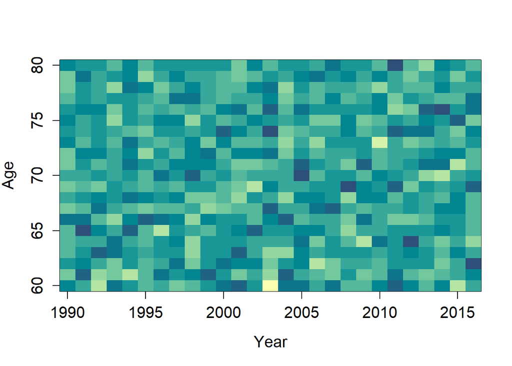

```r
agesForecast <- seq(60,80, 1)
yearsForecast <- 1990:2016

rateForecastTrue <- dplyr::filter(mortData,age %in% agesForecast, year %in% yearsForecast)$rate
rateForecastTrue <- matrix(log(rateForecastTrue),nrow=27);

# build data frame for desired forecasts, then call predict
xPredImage <- data.frame(expand.grid(agesForecast, yearsForecast))
colnames(xPredImage) <- c("age","year")

mortPredImage <- predict(mortModel, newdata=data.frame(x=xPredImage),
                    cov.compute=TRUE,
                    se.compute=TRUE,type="UK")
mortPredImage <- matrix(mortPredImage$m,nrow=27,byrow=TRUE)

# plot residuals heatmap using the image command
image(yearsForecast, agesForecast, rateForecastTrue-mortPredImage,
     xlab="Year", ylab="Age",
     cex.axis=1.3, cex.lab=1.3, cex=1.3,
     col = hcl.colors(12, "BluYl"))
```